# Example - Epigenetic Differential Expression, DMP

Brett Maroni-Rana

```r
# set working directory
#setwd(dirname(rstudioapi::getActiveDocumentContext()$path))
```

### Load Data

Raw data has been processed previously and saved as a quantile normalized, probe filtered, genomic annotated ratio set. Here, the object loaded is **gr_filt.rda**.

## Data Exploration

### QC check : PCA most variable probes

Prior to batch corrections and further analysis, the most variable probes according to m-value standard deviation can visualized with PCA. This quick QC check assess distribution of the two most important aspects of the data, principal component 1 and principal component 2. This looks at covariation and can determine if covariates need to be accounted for if the distribution is not random. Batch correction and SVA can account for covariation.

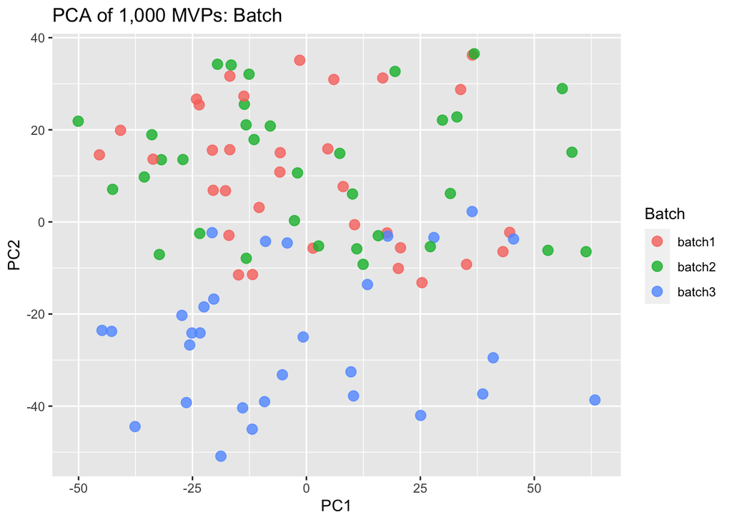

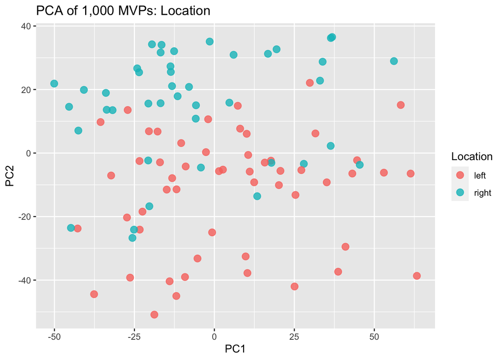

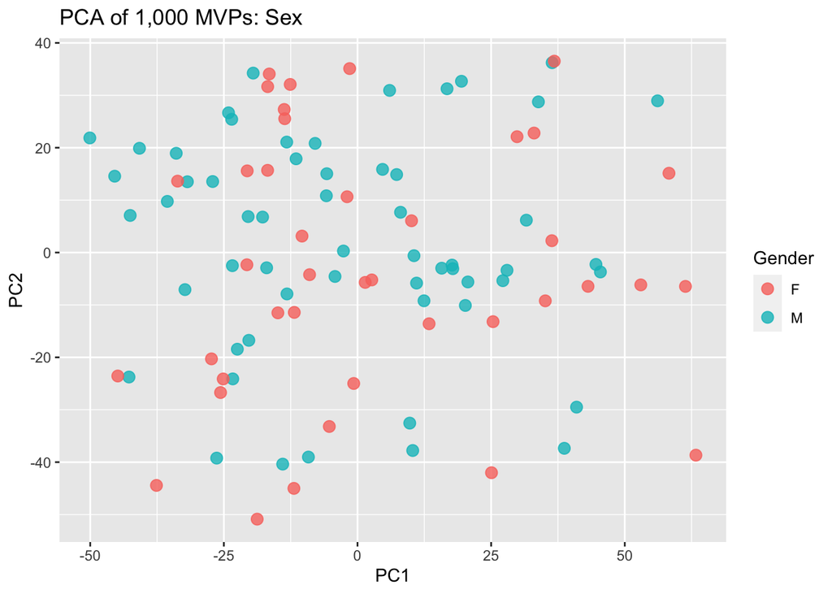

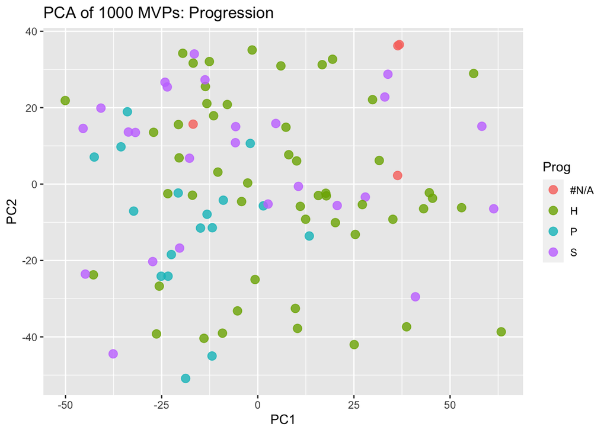

PCA analysis on the top 1000 most variable probes by standard deviation shows a few interesting patterns.

- **Batch**: Significant batch effect. Batch 1 and 2 seem random. Batch 3 concentrates toward negative PC2. There is a need for batch correction.
- **Location**: Distinct distribution of PCs between left and right sided colon samples. This is a biological affect and should be preserved, although analyzing these samples separately according to location may aid in analysis.
- **Gender**: Seemingly randomly distributed
- **Progression**: High progressor is randomly distributed. Progressor and Static have unique patterns, P more than S. This indicates the methylation signitures are different between the three groups and warrents further investigation

### Goals of Study

Following PCA, how can the samples best be characterized? and what are the goals of this study?

1. What are the differentially expressed CpGs between potential progressor phenotypes?
2. Of those DMPs, are they found close together in differentially expressed regions?
3. What are the characterisitics DMPs?

### Combat : Batch Effect Removal

Accounting for and removing known and unknown variability in an experiment can reduce error rates. To do so, two methods are used and can be found within the **sva** R package. The first of these functions is *ComBat()* in which an empirical Bayesian framework is applied to the dataset. Once batch effects are removed, unknown variability can be removed with *sva()* or further processed with downstream analysis.

comBat code and visualization is below:

```r
# set model matrix
mod = model.matrix(~ gr_filt$progression +
                     gr_filt$location)
# run batch correction
m_value_combat <- ComBat(dat = m_value,
                         mod = mod,
                         batch = gr_filt$batch)
```

```
#> Found3batches
#> Adjusting for4covariate(s) or covariate level(s)
#> Standardizing Data across genes
#> Fitting L/S model and finding priors
#> Finding parametric adjustments
#> Adjusting the Data
```

```r
# get beta
beta_combat <- ilogit2(m_value_combat)
```

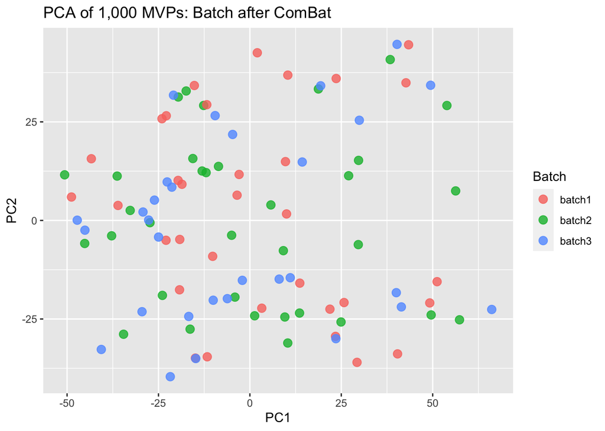

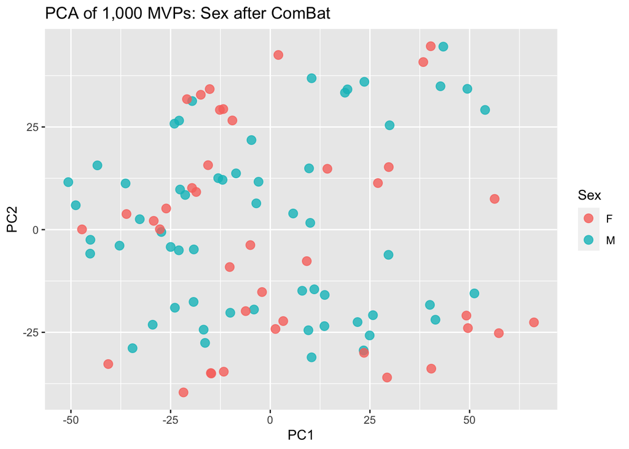

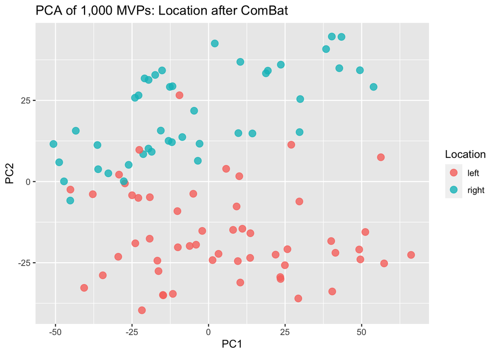

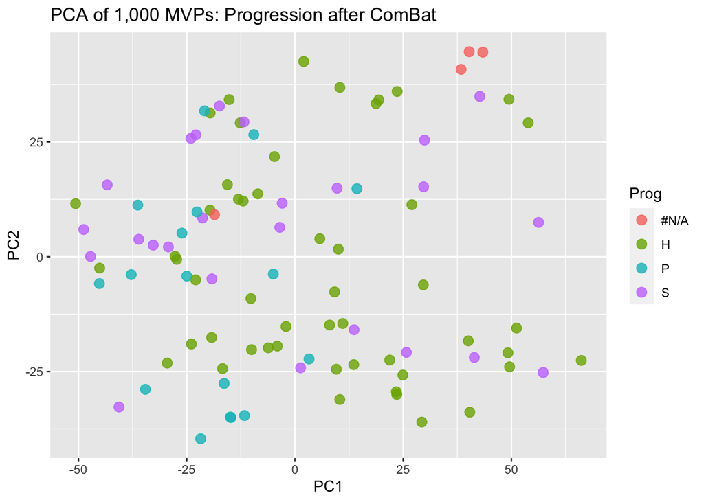

Following batch correction and the PCA plotting of 1,000 most variable probes, batch 3 looks to be more randomly distributed. Before batch correction, batch 3 is slightly more distributed toward a negative PC1 and PC2. After batch correction, batch 3 is slightly more distributed toward a positive PC2 resulting in a slight more evenly distributed batch.

Importantly, Progression and Location are relatively unchanged with their distinct patterns remaining.

### Surrogate Variable Analysis (SVA)

Surrogate Variable Analysis removes unknown variability in a dataset by first estimating surrogate variables, then by including them into a model. In this study, the surrogate variables are used in the limma package along with the variables from the data.

Importantly, this study focuses on methylation expression vs potential progression, without interest in demographics. If demographics were integral to this analysis, sva may not be appropriate in an effort to preserve the integrity of the demographic data. Polyp location is exception of this and is not included in SVA model.

Covariates taken into consideration and correcting for include final age and sex. Additional phenotypic data may be appropriate.

sva code is below:

```r
# sva for surrogate variables
mod <- model.matrix(~ gr_filt$progression +
                      gr_filt$age_t0 +
                      gr_filt$sex)

mod0 <- model.matrix(~ gr_filt$age_t0 +
                       gr_filt$sex)

svobj <- sva(dat = m_value_combat, mod = mod, mod0 = mod0) # 17 variables
```

```
#> Number of significant surrogate variables is:  17
#> Iteration (out of 5 ):1  2  3  4  5
```

```r
#save(svobj, file='svobj.rda')
```

### EWAS : Linear Models for Microarray Data (limma)

Next, a linear model can be fit to our data using the limma package. An experiment is designed with model.matrix and used to distinguish phenotypic differences between samples. This experimental design and methylation data matrix is used by lmFit to fit linear models to each row of the data. Each row in our methylation matrix corresponds to a CpG probe. Finally, a moderated t-statistic and log-odds of differential expression is calculated with eBayes and summarized using topTable. Differntially methylated probes can be annotated downstream or visualized together in a heatmap. See below:

```r
# EWAS DMP analysis with limma
# single comparison
fit <- eBayes(lmFit(m_value_combat,
                    model.matrix(~ gr_filt$progression +
                                   gr_filt$location +
                                   svobj$sv)), robust = T)

res <- topTable(fit, coef = 2, number = nrow(m_value_combat))
res <- res[,c(1,4,5)]
colnames(res) <- c("logFC", "pval","adj_pval")
```

**Top CpGs**  
Criteria: adjusted p-value < 0.05 and absolute LogFC >= 1.5

```r
# limma summary
top_cpgs <- sum(res$adj_pval < 0.05 & abs(res$logFC) > 1.5)
cat("Top CpGs:", top_cpgs)
```

```
#> Top CpGs: 67
```

**Annotation**  
Each CpG probe has accompanying annotatin data from Illumina. Minfi package is used to retrieve the annotation for downstream anlaysis.

DMPs are annotated and written as a tab-delimited text file. **See “result_dmp.txt”** *example RMD does not write to file*

```r
# example - dmp annotation
head(res)
```

[output not shown]

```r
# write to .csv
#write.table(res, 'result_dmp.txt', sep='\t', quote = F)

# save to .rda
#save(res, file='res.rda')
```

## Visualization

### Heatmap with Top CpGs

**Get Top CpGs**  
Following DMP analysis with Limma, we can visualize the results in a heatmap. We can get the most statistically relevant results by filtering our results with an FDR adjusted p-value < 0.05 and log2FC > +-1.5

|  | chr | pos | strand | Islands_Name | Relation_to_Island | UCSC_RefGene_Name | UCSC_RefGene_Accession | UCSC_RefGene_Group | logFC | pval | adj_pval |
| --- | --- | --- | --- | --- | --- | --- | --- | --- | --- | --- | --- |
| cg06025396 | chr14 | 57949967 | + |  | OpenSea | C14orf105 | NM_001283059;NM_001283058;NM_001283057;NM_001283056;NM_018168;NM_001283060 | Body | 1.575336 | 1.903304e-09 | 0.0001822487 |
| cg04850548 | chr5 | 43192428 | + | chr5:43191974-43193155 | Island | MGC42105 | NM_153361;NM_153361 | 1stExon;5'UTR | -2.085633 | 2.392870e-09 | 0.0001848980 |
| cg12062668 | chr13 | 36166637 | + |  | OpenSea | MIR548F5;NBEA | NR_031646;NM_001204197;NM_015678 | Body | 1.590306 | 3.472825e-09 | 0.0001916761 |
| cg14510504 | chr13 | 77566830 | - | chr13:77566089-77566599 | S_Shore | CLN5 | NM_006493 | Body | 2.074940 | 6.668532e-09 | 0.0003435201 |
| cg11837293 | chr20 | 52356911 | - |  | OpenSea |  |  |  | 2.276037 | 1.121687e-08 | 0.0004561746 |
| cg26023748 | chr10 | 54515151 | - |  | OpenSea |  |  |  | 1.571400 | 2.725454e-08 | 0.0008423876 |

**Generate Heatmap**  
The heatmap package *pheatmap* is used to generate a heatmap and includes a hierarchical clustering method. Here, default settings of *hclust()* are used. Euclidean distance is measured between samples, based on thier methylation value, while complete linkage clustering option is used to generate a dendogram.

[figure not shown]